# Week 3 DS Recitation

SIBDS 2024 @ Columbia

15 June, 2024

## Getting Started

### Tasks:

1. Create a new R project and named it `Week 3 DS Recitation`
2. Put the `week_3_DS_recitation.Rmd` file into the same folder of the R project you just created.
3. Modify the YAML header as follows:

```
---
title: "Week 3 DS Recitation"
date: "15 June, 2024"
author: "SIBDS 2024 @ Columbia"
output:
  html_document:
    toc: true
    code_folding: "show"
---
```

Now, knit this `.Rmd` file to make sure it runs as expected.

4. Finally, create a folder within the project folder named `data`. Put the data files we downloaded in Tuesday’s class in to this folder.

## Writing with Data

### Tasks:

1. Write a named code chunk names `sample_df` that creates a dataframe comprised of
   - `random_vec` : A `numeric` variable containing a random sample of size `500` from a normal variable with mean `1` and standard deviation `3`.
   - `logical_vec` : A `logical` vector indicating whether each sampled value is greater than zero, can you do it in the simplest way?
   - `abs_vec`: A `numeric` vector containing the absolute value (using `abs()`) of each element.

```r
# Your answer starts here:
df1 <- tibble(
random_vec = rnorm(500, mean = 1, sd = 3),
logical_vec = random_vec > 0,
abs_vec = abs(random_vec)
)
```

2. Produce a histogram of the absolute value variable just created.

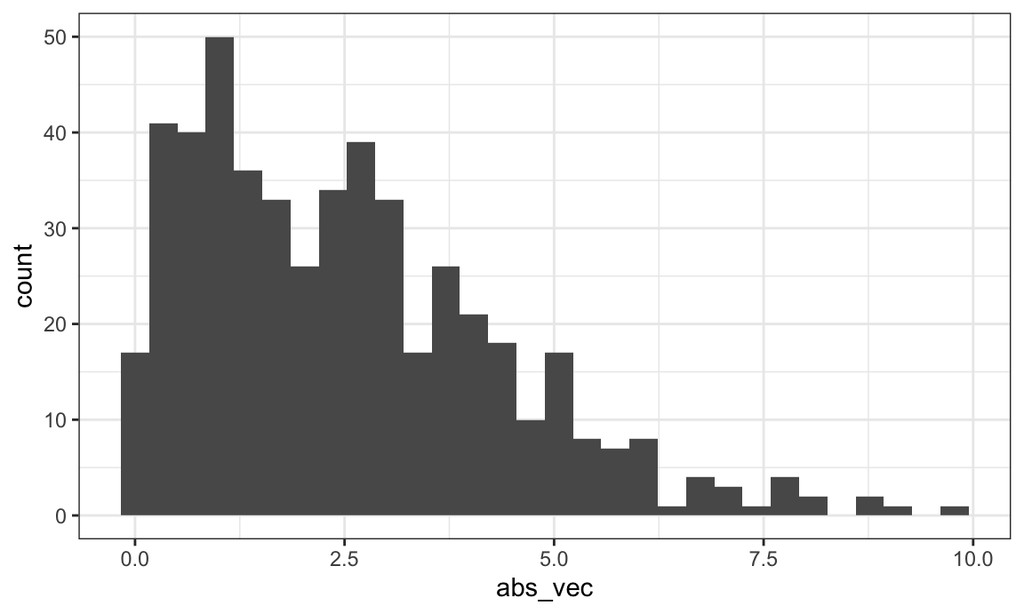

```r
# Your answer starts here:
ggplot(aes(x = abs_vec), data = df1) + geom_histogram()
```

```r
#df1 %>% ggplot(aes(x = abs_vec)) + geom_histogram()
```

4. Fill in the blank using the in-line code giving the mean, median, and standard deviation of `random_vec` (*Hint*: you may need to use the `pull()` function and in `tidyverse`), round them to two decimal places.
   - Mean: 1.15
   - Median: 1.23
   - SD: 2.91

## Data Import

### Tasks:

1. Load the `FAS_pups.csv` dataset. Use both absolute and relative paths

```r
# Your answer starts here:
working_dir = getwd()
data_dir = paste0(working_dir,"/data/FAS_pups.csv")
# absolute path
pups = read_csv(data_dir)
pups = janitor::clean_names(pups)
# relative path
pups = read_csv("./data/FAS_pups.csv")
pups = janitor::clean_names(pups)

# Take a quick look of your dataset
head(pups, 5)
```

```
## # A tibble: 5 × 6
##   litter_number   sex pd_ears pd_eyes pd_pivot pd_walk
##   <chr>         <dbl>   <dbl>   <dbl>    <dbl>   <dbl>
## 1 #85               1       4      13        7      11
## 2 #85               1       4      13        7      12
## 3 #1/2/95/2         1       5      13        7       9
## 4 #1/2/95/2         1       5      13        8      10
## 5 #5/5/3/83/3-3     1       5      13        8      10
```

```r
skimr::skim(pups)
```

Data summary

| Name | pups |
| --- | --- |
| Number of rows | 313 |
| Number of columns | 6 |
| _______________________ |  |
| Column type frequency: |  |
| character | 1 |
| numeric | 5 |
| ________________________ |  |
| Group variables | None |

**Variable type: character**

| skim_variable | n_missing | complete_rate | min | max | empty | n_unique | whitespace |
| --- | --- | --- | --- | --- | --- | --- | --- |
| litter_number | 0 | 1 | 3 | 15 | 0 | 49 | 0 |

**Variable type: numeric**

| skim_variable | n_missing | complete_rate | mean | sd | p0 | p25 | p50 | p75 | p100 | hist |
| --- | --- | --- | --- | --- | --- | --- | --- | --- | --- | --- |
| sex | 0 | 1.00 | 1.50 | 0.50 | 1 | 1 | 2 | 2 | 2 | ▇▁▁▁▇ |
| pd_ears | 18 | 0.94 | 3.68 | 0.59 | 2 | 3 | 4 | 4 | 5 | ▁▅▁▇▁ |
| pd_eyes | 13 | 0.96 | 12.99 | 0.62 | 12 | 13 | 13 | 13 | 15 | ▂▇▁▂▁ |
| pd_pivot | 13 | 0.96 | 7.09 | 1.51 | 4 | 6 | 7 | 8 | 12 | ▂▇▂▂▁ |
| pd_walk | 0 | 1.00 | 9.50 | 1.34 | 7 | 9 | 9 | 10 | 14 | ▆▇▇▂▁ |

2. Import the `FAS_pups.csv` again with column specifications by setting the `col_type` arguments. What happens if your specifications for column parsing aren’t reasonable (e.g. character instead of double, or vice versa)?

```r
pups = read_csv("./data/FAS_pups.csv", col_types = "cddddd")
pups = janitor::clean_names(pups)
skimr::skim(pups)
```

Data summary

| Name | pups |
| --- | --- |
| Number of rows | 313 |
| Number of columns | 6 |
| _______________________ |  |
| Column type frequency: |  |
| character | 1 |
| numeric | 5 |
| ________________________ |  |
| Group variables | None |

**Variable type: character**

| skim_variable | n_missing | complete_rate | min | max | empty | n_unique | whitespace |
| --- | --- | --- | --- | --- | --- | --- | --- |
| litter_number | 0 | 1 | 3 | 15 | 0 | 49 | 0 |

**Variable type: numeric**

| skim_variable | n_missing | complete_rate | mean | sd | p0 | p25 | p50 | p75 | p100 | hist |
| --- | --- | --- | --- | --- | --- | --- | --- | --- | --- | --- |
| sex | 0 | 1.00 | 1.50 | 0.50 | 1 | 1 | 2 | 2 | 2 | ▇▁▁▁▇ |
| pd_ears | 18 | 0.94 | 3.68 | 0.59 | 2 | 3 | 4 | 4 | 5 | ▁▅▁▇▁ |
| pd_eyes | 13 | 0.96 | 12.99 | 0.62 | 12 | 13 | 13 | 13 | 15 | ▂▇▁▂▁ |
| pd_pivot | 13 | 0.96 | 7.09 | 1.51 | 4 | 6 | 7 | 8 | 12 | ▂▇▂▂▁ |
| pd_walk | 0 | 1.00 | 9.50 | 1.34 | 7 | 9 | 9 | 10 | 14 | ▆▇▇▂▁ |

```r
# character instead of double
pups_bad = read_csv("./data/FAS_pups.csv", col_types = "cccccc")
pups_bad = janitor::clean_names(pups_bad)
skimr::skim(pups_bad)
```

Data summary

| Name | pups_bad |
| --- | --- |
| Number of rows | 313 |
| Number of columns | 6 |
| _______________________ |  |
| Column type frequency: |  |
| character | 6 |
| ________________________ |  |
| Group variables | None |

**Variable type: character**

| skim_variable | n_missing | complete_rate | min | max | empty | n_unique | whitespace |
| --- | --- | --- | --- | --- | --- | --- | --- |
| litter_number | 0 | 1.00 | 3 | 15 | 0 | 49 | 0 |
| sex | 0 | 1.00 | 1 | 1 | 0 | 2 | 0 |
| pd_ears | 18 | 0.94 | 1 | 1 | 0 | 4 | 0 |
| pd_eyes | 13 | 0.96 | 2 | 2 | 0 | 4 | 0 |
| pd_pivot | 13 | 0.96 | 1 | 2 | 0 | 9 | 0 |
| pd_walk | 0 | 1.00 | 1 | 2 | 0 | 8 | 0 |

```r
# double instead of character
pups_bad_2 = read_csv("./data/FAS_pups.csv", col_types = "dddddd")
pups_bad_2 = janitor::clean_names(pups_bad_2)
skimr::skim(pups_bad_2)
```

Data summary

| Name | pups_bad_2 |
| --- | --- |
| Number of rows | 313 |
| Number of columns | 6 |
| _______________________ |  |
| Column type frequency: |  |
| numeric | 6 |
| ________________________ |  |
| Group variables | None |

**Variable type: numeric**

| skim_variable | n_missing | complete_rate | mean | sd | p0 | p25 | p50 | p75 | p100 | hist |
| --- | --- | --- | --- | --- | --- | --- | --- | --- | --- | --- |
| litter_number | 313 | 0.00 | NaN | NA | NA | NA | NA | NA | NA |  |
| sex | 0 | 1.00 | 1.50 | 0.50 | 1 | 1 | 2 | 2 | 2 | ▇▁▁▁▇ |
| pd_ears | 18 | 0.94 | 3.68 | 0.59 | 2 | 3 | 4 | 4 | 5 | ▁▅▁▇▁ |
| pd_eyes | 13 | 0.96 | 12.99 | 0.62 | 12 | 13 | 13 | 13 | 15 | ▂▇▁▂▁ |
| pd_pivot | 13 | 0.96 | 7.09 | 1.51 | 4 | 6 | 7 | 8 | 12 | ▂▇▂▂▁ |
| pd_walk | 0 | 1.00 | 9.50 | 1.34 | 7 | 9 | 9 | 10 | 14 | ▆▇▇▂▁ |

## Data Manipulation

### Tasks:

1. In the pups data, do the following:
   1. select the columns containing litter number, sex, and PD ears
   2. Filter to include only pups with `sex == 1`
   3. Filter to include only pups with `pd_walk` less than 11 and `sex == 2`
   4. Create a variable that subtracts 7 from `pd_pivot`
   5. Create a variable that is the sum of all the `pd` variables
   6. Sort the variable `pd_eyes` in ascending order and `pd_walk` in descending order

```r
# a
select(pups, litter_number, sex, pd_ears)
```

```
## # A tibble: 313 × 3
##    litter_number   sex pd_ears
##    <chr>         <dbl>   <dbl>
##  1 #85               1       4
##  2 #85               1       4
##  3 #1/2/95/2         1       5
##  4 #1/2/95/2         1       5
##  5 #5/5/3/83/3-3     1       5
##  6 #5/5/3/83/3-3     1       5
##  7 #5/4/2/95/2       1      NA
##  8 #4/2/95/3-3       1       4
##  9 #4/2/95/3-3       1       4
## 10 #2/2/95/3-2       1       4
## # ℹ 303 more rows
```

```r
# b
filter(pups, sex == 1)
```

```
## # A tibble: 155 × 6
##    litter_number   sex pd_ears pd_eyes pd_pivot pd_walk
##    <chr>         <dbl>   <dbl>   <dbl>    <dbl>   <dbl>
##  1 #85               1       4      13        7      11
##  2 #85               1       4      13        7      12
##  3 #1/2/95/2         1       5      13        7       9
##  4 #1/2/95/2         1       5      13        8      10
##  5 #5/5/3/83/3-3     1       5      13        8      10
##  6 #5/5/3/83/3-3     1       5      14        6       9
##  7 #5/4/2/95/2       1      NA      14        5       9
##  8 #4/2/95/3-3       1       4      13        6       8
##  9 #4/2/95/3-3       1       4      13        7       9
## 10 #2/2/95/3-2       1       4      NA        8      10
## # ℹ 145 more rows
```

```r
# c
filter(pups, pd_walk < 11 & sex == 2)
```

```
## # A tibble: 127 × 6
##    litter_number   sex pd_ears pd_eyes pd_pivot pd_walk
##    <chr>         <dbl>   <dbl>   <dbl>    <dbl>   <dbl>
##  1 #1/2/95/2         2       4      13        7       9
##  2 #1/2/95/2         2       4      13        7      10
##  3 #1/2/95/2         2       5      13        8      10
##  4 #1/2/95/2         2       5      13        8      10
##  5 #1/2/95/2         2       5      13        6      10
##  6 #5/5/3/83/3-3     2       5      13        8      10
##  7 #5/5/3/83/3-3     2       5      14        7      10
##  8 #5/5/3/83/3-3     2       5      14        8      10
##  9 #5/4/2/95/2       2      NA      14        7      10
## 10 #5/4/2/95/2       2      NA      14        7      10
## # ℹ 117 more rows
```

```r
# d
mutate(pups, pd_pivot_7 = pd_pivot - 7)
```

```
## # A tibble: 313 × 7
##    litter_number   sex pd_ears pd_eyes pd_pivot pd_walk pd_pivot_7
##    <chr>         <dbl>   <dbl>   <dbl>    <dbl>   <dbl>      <dbl>
##  1 #85               1       4      13        7      11          0
##  2 #85               1       4      13        7      12          0
##  3 #1/2/95/2         1       5      13        7       9          0
##  4 #1/2/95/2         1       5      13        8      10          1
##  5 #5/5/3/83/3-3     1       5      13        8      10          1
##  6 #5/5/3/83/3-3     1       5      14        6       9         -1
##  7 #5/4/2/95/2       1      NA      14        5       9         -2
##  8 #4/2/95/3-3       1       4      13        6       8         -1
##  9 #4/2/95/3-3       1       4      13        7       9          0
## 10 #2/2/95/3-2       1       4      NA        8      10          1
## # ℹ 303 more rows
```

```r
# e
mutate(pups, pd_sum = pd_ears + pd_eyes + pd_pivot + pd_walk)
```

```
## # A tibble: 313 × 7
##    litter_number   sex pd_ears pd_eyes pd_pivot pd_walk pd_sum
##    <chr>         <dbl>   <dbl>   <dbl>    <dbl>   <dbl>  <dbl>
##  1 #85               1       4      13        7      11     35
##  2 #85               1       4      13        7      12     36
##  3 #1/2/95/2         1       5      13        7       9     34
##  4 #1/2/95/2         1       5      13        8      10     36
##  5 #5/5/3/83/3-3     1       5      13        8      10     36
##  6 #5/5/3/83/3-3     1       5      14        6       9     34
##  7 #5/4/2/95/2       1      NA      14        5       9     NA
##  8 #4/2/95/3-3       1       4      13        6       8     31
##  9 #4/2/95/3-3       1       4      13        7       9     33
## 10 #2/2/95/3-2       1       4      NA        8      10     NA
## # ℹ 303 more rows
```

```r
# f
arrange(pups, pd_eyes, desc(pd_walk))
```

```
## # A tibble: 313 × 6
##    litter_number   sex pd_ears pd_eyes pd_pivot pd_walk
##    <chr>         <dbl>   <dbl>   <dbl>    <dbl>   <dbl>
##  1 #101              1       3      12       10      12
##  2 #101              2       3      12        9      12
##  3 #101              1       4      12        6      11
##  4 #85/2             2       4      12        9      11
##  5 #101              2       4      12        9      11
##  6 #101              2       4      12        8      11
##  7 #100              2       3      12        9      11
##  8 #100              2       4      12        9      11
##  9 #84/2             2       3      12        8      10
## 10 #101              2       3      12        6      10
## # ℹ 303 more rows
```

2. Write a chain of commands that:
   - Loads the `pups` data from `FAS_pups.csv`
   - Cleans the variable names
   - Filters the data to include only `pups` with `sex == 1`
   - Removes the `pd_ears` variable
   - Creates a variable that indicates whether `pd_pivot` is 7 or more days